# Coursera statinference-006 course project

Raymond Nelson

September 12, 2014

# Simulation of an Exponential Distribution

## Assignment

The exponential distribution can be simulated in R with rexp(n, lambda) where lambda is the rate parameter.

The mean of exponential distribution is 1/lambda and the standard deviation is also also 1/lambda.

Set lambda = 0.2 for all of the simulations.

In this simulation, you will investigate the distribution of averages of 40 exponential(0.2)s. Note that you will need to do a thousand or so simulated averages of 40 exponentials.

## Instructions

Illustrate via simulation and associated explanatory text the properties of the distribution of the mean of 40 exponential(0.2)s.

## Preliminaries

First set the working directory.

```r
setwd("~/Documents/RAYMOND/Coursera/Statistical Inference 9-1-2014 to 9-29-2014/statInfProject")
```

Then construct the replications of the simulated distribution of 1000 iterations of 40 random exponential variables with lambda = .2

```r
numVars <- 40
numSim <- 1000
lambda <- .2

# construct the NULL matrix to hold the data
# 40 columns represent random exp values
# 1000 rows will hold the results of the simulation run

set.seed(1234)
simMatrix <- matrix(rexp(numSim * numVars, lambda), numSim)
```

## Project questions

```r
# using rowMeans
rm <- rowMeans(simMatrix)
m <- mean(rm)

# another method using apply
m <- mean(apply(simMatrix, 1, mean))

# the theoretical center of the distribution is 1 / lambda
tm <- 1 / lambda
```

### 2. Show how variable it is and compare it to the theoretical variance of the distribution.

```r
# calculation of the sampling SD is done with apply
s <- mean(apply(simMatrix, 1, sd))
# standard deviation
s
```

```
## [1] 4.835
```

```r
# variance
s^2
```

```
## [1] 23.37
```

```r
# the theoretical SD of the distribution is 1 / lambda for which the square is the variance.
tsd <- 1 / lambda
tsd^2
```

```
## [1] 25
```

### 3. Show that the distribution is approximately normal.

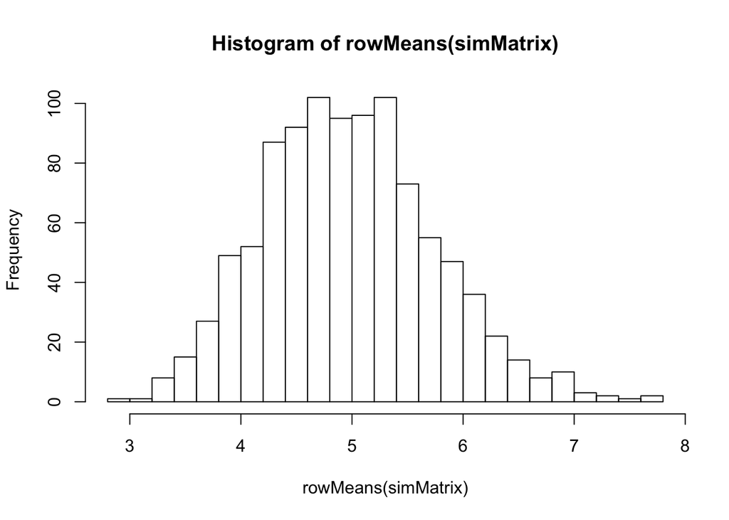

```r
# histogram to evaluate normality of the distribution
hist(rowMeans(simMatrix), breaks = 30)
```

Another example with ggplot.

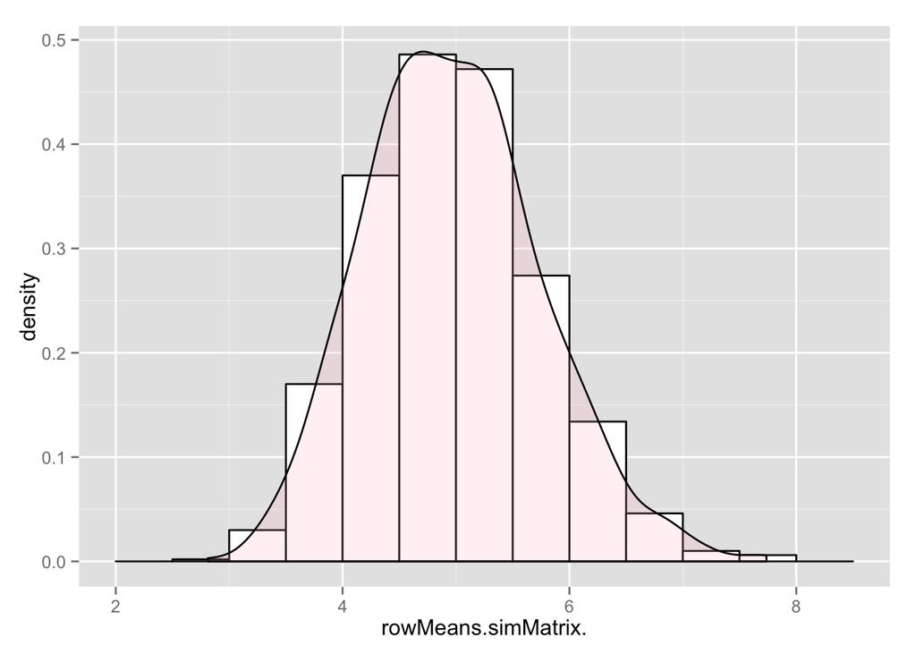

```r
library(ggplot2)
rm <- data.frame(rowMeans(simMatrix))
ggplot(rm, aes(x=rowMeans.simMatrix.)) +
        geom_histogram(aes(y=..density..),
                       binwidth=.5,
                       colour="black", fill="white") +
        geom_density(alpha=.2, fill="pink")
```

```r
# first calculate the standard error of the SD of the simulated distribution
# upper limit
ul <- s + 1.9599 * (s / sqrt(numSim))
ul
```

```
## [1] 5.134
```

```r
# lower limit
ll <- s - 1.9599 * (s / sqrt(numSim))
ll
```

```
## [1] 4.535
```